# Bayesian Logistic Regression

Next, we would like to fit a Bayesian model. While a frequentist assumes that there are true values of the parameters of the model and computes the point estimates of the parameters, a Bayesian asserts that only data are real, and treats the model parameters as probability distributions which are to be inferred.

The four steps of a Bayesian analysis are:

1. Specify a joint distribution for the outcome(s) and all the unknowns, which typically takes the form of a marginal prior distribution for the unknowns multiplied by a likelihood for the outcome(s) conditional on the unknowns. This joint distribution is proportional to a posterior distribution of the unknowns conditional on the observed data
2. Draw from posterior distribution using Markov Chain Monte Carlo (MCMC).
3. Evaluate how well the model fits the data and possibly revise the model.
4. Draw from the posterior predictive distribution of the outcome(s) given interesting values of the predictors in order to visualize how a manipulation of a predictor affects (a function of) the outcome(s).

To run this model using Bayesian estimation, we can use the `rstanarm` package. This package wraps Stan code for common regression models. In contrast with the frequentist procedure, in Bayesian estimation we need to specify priors for our parameters. The `rstanarm` function equivalent of g`lm()` is `stan_glm()`, which supports every link function that `glm()` supports. Rather than generate point estimates and a covariance, Stan instead **simulates draws from the posterior distribution of our parameters** using a sophisticated algorithm called Hamiltonian Monte Carlo. Stan output is a matrix in which each row is a simulated draw from the posterior and each column is a parameter (or function of parameters). With `stan_glm()`, binomial models with a logit link function can typically be fit slightly faster than the identical model with a probit link because of how the two models are implemented in Stan. In the following code, we simply specify the chosen link, and set priors for the intercept and the predictor coefficients.

### Model Fitting

First, we set a seed so that we get the same results for randomization. Then, to reduce time-complexity that `stan_glm()` needs to fit a model, we sample 5000 from the 68707 observations.

```r
seed <- 1
d1 <- sample_n(d, 5000)
```

In the following code, we specified the chosen link, and set priors for the intercept and the predictor coefficients.

```r
post1 <- stan_glm(status ~ loan_amount + sector + posted_yr + continent + sex, data = d1,
                 family = binomial(link = "logit"),
                 prior = normal(0,1), prior_intercept = normal(0,1),
                 seed = seed,
                 refresh = 0,
                 cores=3, chains = 3,warmup = 500,iter = 1200)
```

Here’s the output of the model:

```r
post1
```

```
## stan_glm
##  family:       binomial [logit]
##  formula:      status ~ loan_amount + sector + posted_yr + continent + sex
##  observations: 5000
##  predictors:   23
## ------
##                      Median MAD_SD
## (Intercept)          -778.6  144.9
## loan_amount             0.0    0.0
## sectorArts              0.5    0.6
## sectorClothing          0.5    0.4
## sectorConstruction      0.0    0.5
## sectorEducation         0.4    0.8
## sectorEntertainment     0.1    1.0
## sectorFood              0.3    0.3
## sectorHealth            0.8    0.8
## sectorHousing          -0.2    0.6
## sectorManufacturing    -0.2    0.6
## sectorPersonal Use      0.5    0.8
## sectorRetail            0.2    0.3
## sectorServices         -0.3    0.3
## sectorTransportation    0.4    0.5
## sectorWholesale         0.4    0.9
## posted_yr               0.4    0.1
## continentAmericas       0.6    0.2
## continentAsia           1.0    0.2
## continentEurope         1.1    0.7
## continentOceania        1.2    0.7
## sexmale                 0.1    0.2
## sexmixed               -0.4    0.4
##
## ------
## * For help interpreting the printed output see ?print.stanreg
## * For info on the priors used see ?prior_summary.stanreg
```

Next, we would like to draw a caterpillar plot, which displays the median and estimate interval for all the coefficients sorted by their medians so that we can get a closer look at which variables are expected to have greater effects on the response variable. First, we sort the predictor variables in our model `post1` by coefficients. To do this, we extract the `coefficient` element from `post1` and converted it into a data frame which has only one column “post1.coefficients”; we then sorted the rows based on the value of the coefficients. Next, we extracted the row names except for the first row (the intercept) and store it for use in drawing the caterpillar plot.

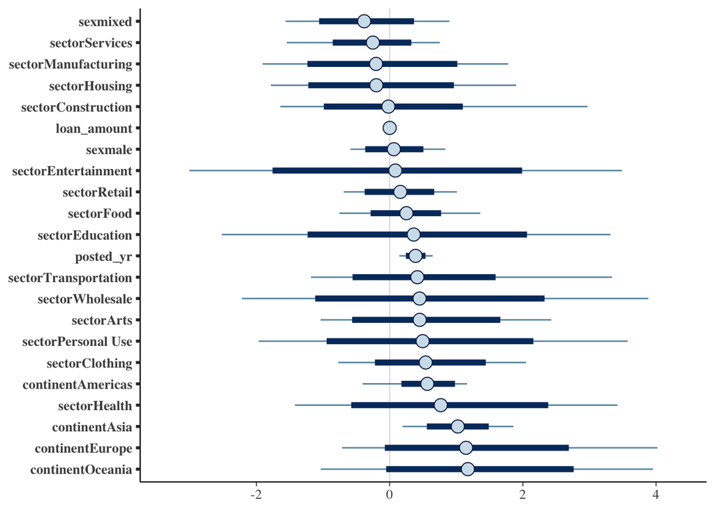

```r
coef <- data.frame(post1$coefficients) %>%
  arrange(post1.coefficients)
order <- rownames(coef)[-1]

cate <- mcmc_intervals(as.matrix(post1), pars = order, prob = 0.95, prob_outer = 1)
cate
```

This caterpillar plot created by the `mcmc_intervals()` function in the `bayesplot` package. It plots the 95% uncertainty intervals computed from posterior draws with all chains merged. The intervals are sorted by the median of each coefficient.

### Model Evaluation

```r
(loo1 <- loo(post1, save_psis = TRUE))
```

```
##
## Computed from 2100 by 5000 log-likelihood matrix
##
##          Estimate   SE
## elpd_loo   -539.9 38.6
## p_loo        13.8  1.5
## looic      1079.8 77.1
## ------
## Monte Carlo SE of elpd_loo is 0.1.
##
## All Pareto k estimates are good (k < 0.5).
## See help('pareto-k-diagnostic') for details.
```

In the code chunk above, we assessed the strength of our model via its posterior predictive LOOCV (Leave One Out Cross-Validation). We can see from the output that PSIS-LOO result is reliable as all Pareto k estimates are small (k< 0.5). However as we know, this accuracy rate is quite meaningless unless we have something to compare it to. So we created a baseline model with no predictors for comparison:

```r
post0 <- stan_glm(status ~ 1, data = d1,
                 family = binomial(link = "logit"),
                 prior = normal(0,1), prior_intercept = normal(0,1),
                 seed = seed,
                 refresh = 0,
                 cores=3, chains = 3, warmup = 500,iter = 1200)
```

```r
(loo0 <- loo(post0, save_psis = T))
```

```
##
## Computed from 2100 by 5000 log-likelihood matrix
##
##          Estimate   SE
## elpd_loo   -563.5 39.8
## p_loo         1.1  0.1
## looic      1127.1 79.6
## ------
## Monte Carlo SE of elpd_loo is 0.0.
##
## All Pareto k estimates are good (k < 0.5).
## See help('pareto-k-diagnostic') for details.
```

```r
rstanarm::compare_models(loo0, loo1)
```

```
## Model formulas:
##  :  NULL
##  :  NULLelpd_diff        se
##      23.6       8.5
```

Since difference is positive, the expected predictive accuracy for the second model (post1) is higher.

Below, we compute posterior predictive probabilities of the linear predictor via the `posterior_linpred()` function provided in the `rstanarm` package. This function will extract posterior draws from the linear predictor. If we used a link function, then specifying the transform argument as `TRUE` will return the predictor as transformed via the inverse-link.

```r
preds <- posterior_linpred(post1, transform=TRUE)
pred <- colMeans(preds)
```

We calculate these posterior predictive probabilities in order to determine the classification accuracy of our model. If the posterior probability of success for an individual is greater or equal to 0.5, then we would predict that observation to be a success (and similarly for less than 0.5). For each observation, we can compare the posterior prediction to the actual observed value. The proportion of times we correctly predict an individual (i.e. [prediction = 0 and observation = 0] or [prediction = 1 and observation = 1]) is our classification accuracy.

```r
pr <- as.integer(pred >= 0.5)
round(mean(xor(pr,as.integer(d$status==0))),3) #classification accuracy
```

```
## [1] 0.977
```

However, we should really be evaluating the classification accuracy of our model on unseen data. This can be done via a LOOCV approach or by using a test dataset. Here we use the former approach to illustrate the function `E_loo()`, which uses importance weights generated from the `loo()` function.

```r
#evaluating the classification accuracy of our model on unseen data using a test dataset
ploo=E_loo(preds, loo1$psis_object, type="mean", log_ratios = -log_lik(post1))$value
round(mean(xor(ploo>0.5,as.integer(d$status==0))),3)
```

```
## [1] 0.977
```

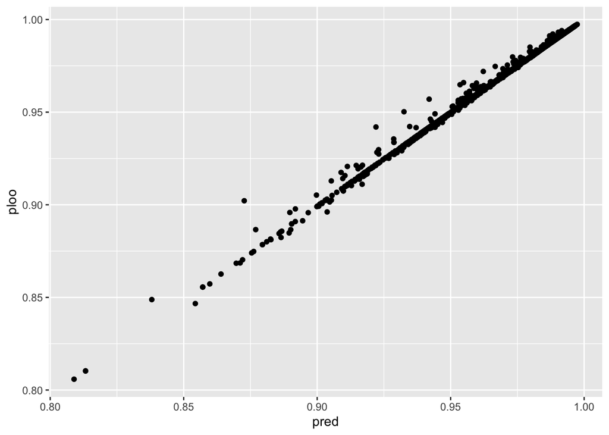

```r
qplot(pred, ploo)
```

In the plot above we can see the small difference in posterior predictive probabilities and LOO probabilities.

We can again use ROC and AUC to evaluate this model. First, we need to prepare a test data set. Here we are extracting data from the original data set that are not in the sample.

```r
train <- d1
test <- setdiff(d, train)
predicted <- predict(post1, newdata=test)
```

Here’s the ROC curve of our model on test data:

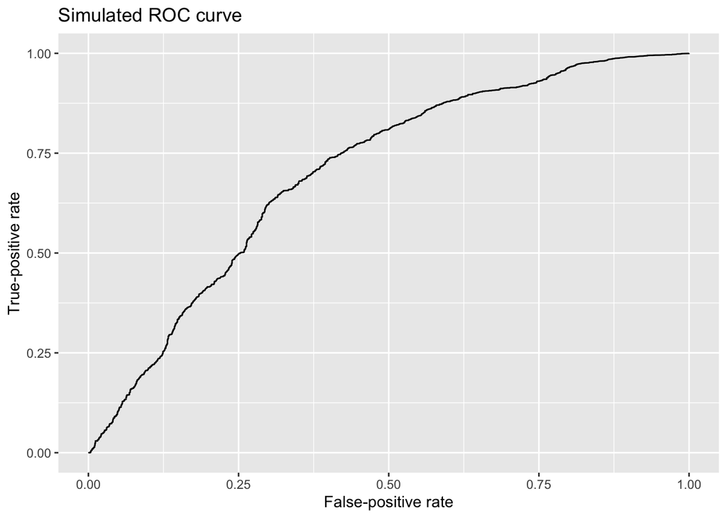

```r
roc = roc(response = test$status, predictor = predicted)
ggroc(roc, legacy.axes = TRUE) +
  labs(x = 'False-positive rate', y = 'True-positive rate', title = 'Simulated ROC curve')
```

```r
auc(test$status,predicted)
```

```
## Area under the curve: 0.703
```

Also, we can save our models in a folder so that RStudio doesn’t need to go through the model fitting process every time we knit the document. Just load the models from where they are stored.